# Murtaugh_SLLOBS_Tidyverse_2019

Charles Murtaugh

7/7/2019

## Introduction

We will be using Tidyverse functions to organize and analyze timelapse proliferation data, from an Incucyte automated microscope, of several mouse pancreatic cancer cell lines. **(Thank you to Shuba Narayan for doing these experiments and providing her data.)** Key points of this experiment are as follows:

- Data are measured as percent confluence within each well
- Five cell lines total, designated: 12738, 12910, 12962, 12965 and 12969
- Cells engineered to express either EGFP (negative control) or Ptf1a, a transcription factor that we hypothesize will inhibit their proliferation
- Transgene expression (EGFP vs Ptf1a) is induced by doxycycline (DOX); untreated cells used as controls
- 3 separate experiments per line, each with 3 technical replicates (i.e. replicate wells) per condition

This analysis was motivated by the finding that although several of the cell lines showed reproducible decreases in growth upon Ptf1a expression, the magnitude of the effect varied from experiment to experiment and it was hard to present the data all together in a convincing way. Could we figure out an easier way to analyze all the data, and a prettier way to graph it? (Yeah I sometimes refer to “data” in the singular.)

I used Excel to assemble all the Incucyte output into a single spreadsheet, `Incucyte_all.txt`. Data columns are named according to overexpressed gene, DOX treatment and technical replicate: thus, `Ptf1a_untreated_1` refers to the first well containing cells with the Ptf1a transgene, not treated with DOX.

Note that you can do all this data assembly and variable renaming within R, using Tidyverse functions. If you have many data files, each with many columns (e.g. multiple RNA-seq read tables), reorganizing in Excel is impractical. While outside the scope of this lecture, I recommend the use of the nested dataframe approach described here: https://serialmentor.com/blog/2016/6/13/reading-and-combining-many-tidy-data-files-in-R

## Data import

Okay, let’s get started by loading the required R packages, clearing any pre-existing data, and reading in the dataset. When you run this code, be sure that the working directory has been set to wherever `Incucyte_all.txt` is located:

```r
library(tidyverse)  # functions for tidy data manipulation
library(cowplot)    # pretty-looking graphs
rm(list=ls())  # clear the decks
options(stringsAsFactors = FALSE)  # useful option for non-Tidyverse work

data_wide <- read_tsv('Incucyte_all.txt') %>% print()
```

```
## # A tibble: 553 x 16
##     Line Elapsed   Date Experiment EGFP_untreated_1 EGFP_untreated_2
##    <dbl>   <dbl>  <dbl>      <dbl>            <dbl>            <dbl>
##  1 12738       0 180116          1             16.2             13.3
##  2 12738       2 180116          1             18.1             14.6
##  3 12738       4 180116          1             17.5             15.9
##  4 12738       6 180116          1             18.0             16.5
##  5 12738       8 180116          1             18.4             16.9
##  6 12738      10 180116          1             19.4             17.8
##  7 12738      12 180116          1             20.1             17.1
##  8 12738      14 180116          1             21.3             17.6
##  9 12738      16 180116          1             22.3             18.1
## 10 12738      18 180116          1             23.1             19.6
## # … with 543 more rows, and 10 more variables: EGFP_untreated_3 <dbl>,
## #   EGFP_DOX_1 <dbl>, EGFP_DOX_2 <dbl>, EGFP_DOX_3 <dbl>,
## #   Ptf1a_untreated_1 <dbl>, Ptf1a_untreated_2 <dbl>,
## #   Ptf1a_untreated_3 <dbl>, Ptf1a_DOX_1 <dbl>, Ptf1a_DOX_2 <dbl>,
## #   Ptf1a_DOX_3 <dbl>
```

If you are used to base R, there are already three weird things here.

1. I used Tidyverse command `read_tsv`, which reads a tab-separated text file into a data frame. You could get almost the same result using the base R command `read.table('Incucyte_all.txt', sep='\t')`.
2. The only difference from `read.table` is that `read_tsv` formats the data frame into a **tibble**, a fancier data frame structure that makes it much easier to quickly look at the contents. When you `print` the contents of a tibble, it shows you only what fits on your console screen, while also telling you what other variables and rows exist. Try importing the same data via `read.table` and then printing it - it’s kind of a mess. Now imagine that your data has 100 or 1000 columns, and think about how it would look in base R! Importantly, though, **all base R functions work normally on tibbles**, it’s just that tibbles look nicer on the screen.
3. I ended the line with `%>% print()`, a great trick I learned on Twitter from Stephen Turner at UVA: https://twitter.com/strnr/status/1047203915232661505. It uses the pipe operator **`%>%`** (keyboard shortcut: `ctrl-shift-M`) to print the output of whatever else your line of code was doing. It does not alter any other work done by the code (e.g. assigning or modifying variables), and it is a quick and easy way to check your work on the fly.

## Data tidying

Now, back to our data. Let’s reorganize it into **tidy** format, i.e. one row per data point, with confluence data as the measured variable.

The key command here is **`gather`**, for which you need to provide four arguments: `gather(data, key, value, ...)` (check the help entry for additional options)

1. `data` is just the wide (spreadsheet-type) data that you wish to convert - in our case, helpfully named `data_wide`
2. `key` is the name you want to use for your new descriptor column, i.e. the names that are currently used for each data column in your spreadsheet - we will call it `treatment_group`
3. `value` is the name you want to use for your new data column - in this case, we are measuring the confluence of individual wells, so we will use that name
4. `...` is where you specify what columns in your spreadsheet contain the data - our first data column is labeled `EGFP_untreated_1` and the last is `Ptf1a_DOX_3`, so we will specify this selection with: `EGFP_untreated_1:Ptf1a_DOX_3`

Note that there are more sophisticated ways to select specific columns using the Tidyverse function **`select`**, which you should read up on.

```r
# convert wide data to narrow/tidy format
data_narrow <- gather(data_wide, key='treatment_group', value='confluence', EGFP_untreated_1:Ptf1a_DOX_3) %>%
  print()
```

```
## # A tibble: 6,636 x 6
##     Line Elapsed   Date Experiment treatment_group  confluence
##    <dbl>   <dbl>  <dbl>      <dbl> <chr>                 <dbl>
##  1 12738       0 180116          1 EGFP_untreated_1       16.2
##  2 12738       2 180116          1 EGFP_untreated_1       18.1
##  3 12738       4 180116          1 EGFP_untreated_1       17.5
##  4 12738       6 180116          1 EGFP_untreated_1       18.0
##  5 12738       8 180116          1 EGFP_untreated_1       18.4
##  6 12738      10 180116          1 EGFP_untreated_1       19.4
##  7 12738      12 180116          1 EGFP_untreated_1       20.1
##  8 12738      14 180116          1 EGFP_untreated_1       21.3
##  9 12738      16 180116          1 EGFP_untreated_1       22.3
## 10 12738      18 180116          1 EGFP_untreated_1       23.1
## # … with 6,626 more rows
```

### Generating new grouping variables with `separate`

`treatment_group` combines multiple data labels into one (as one is forced to do when working with ‘wide’/spreadsheet-style data), which would be much easier to analyze separately. So let’s use the extremely useful Tidyverse command **`separate`**.

```r
# split treatment_group variable into separate variables for overexpressed gene, treatment, and replicate
data_narrow <- separate(data_narrow, treatment_group, c('gene', 'treatment', 'rep')) %>% print()
```

```
## # A tibble: 6,636 x 8
##     Line Elapsed   Date Experiment gene  treatment rep   confluence
##    <dbl>   <dbl>  <dbl>      <dbl> <chr> <chr>     <chr>      <dbl>
##  1 12738       0 180116          1 EGFP  untreated 1           16.2
##  2 12738       2 180116          1 EGFP  untreated 1           18.1
##  3 12738       4 180116          1 EGFP  untreated 1           17.5
##  4 12738       6 180116          1 EGFP  untreated 1           18.0
##  5 12738       8 180116          1 EGFP  untreated 1           18.4
##  6 12738      10 180116          1 EGFP  untreated 1           19.4
##  7 12738      12 180116          1 EGFP  untreated 1           20.1
##  8 12738      14 180116          1 EGFP  untreated 1           21.3
##  9 12738      16 180116          1 EGFP  untreated 1           22.3
## 10 12738      18 180116          1 EGFP  untreated 1           23.1
## # … with 6,626 more rows
```

`separate` defaults to splitting a string of text up by any non-alphanumeric value, so it would work equally well with `EGFP.untreated.1` or even `EGFP:untreated-1`. But if you want to specify the separator, e.g. if you have some punctuation you want to preserve (`EGFP!_untreated_1`), then you can pass the argument `sep='_'`.

We will also convert the treatment info into an **ordered factor**, so that when we plot the data, R will know to graph untreated cells first, then DOX (i.e. control first, then experimental). (Since `EGFP` is alphabetically ahead of `Ptf1a`, R will know to graph them in that order, but you could also convert this variable into an ordered factor if you preferred a different order.) For this, we will use the **`mutate`** command, another one of the MVPs of the Tidyverse.

### Creating new columns or changing existing ones with `mutate` - a toy example

`mutate` is used to create a column in a data frame based on an operation of an existing column. For example, let’s imagine we have a series of temperature measurements in Farenheit that we would like to convert to Celsius:

```r
# create toy data
temp_df <- bind_cols(sample=c(1,2,3), temp=c(-40, 32, 98.6)) %>% print()
```

```
## # A tibble: 3 x 2
##   sample  temp
##    <dbl> <dbl>
## 1      1 -40
## 2      2  32
## 3      3  98.6
```

```r
# use "mutate" to create new column with temperature in Celsius
temp_df <- mutate(temp_df, tempC=(temp-32)*5/9) %>% print()
```

```
## # A tibble: 3 x 3
##   sample  temp tempC
##    <dbl> <dbl> <dbl>
## 1      1 -40     -40
## 2      2  32       0
## 3      3  98.6    37
```

Alternatively, we could have simply replaced the old `temp` variable with a new variable of the same name, but converted to Celsius, with: `temp_df <- mutate(temp_df, temp=(temp-32)*5/9)`. This is the approach we will use with `data_narrow`, below. Before we get to that, let’s check out a nice trick with `mutate`, where we can refer back, within the same command, to a new column that we’ve just created. We’ll also use the pipe operator (`%>%`) and the Tidyverse function `rename` to clean up the column names at the end.

A key point about `%>%`: the next function after the pipe will know that you are sending it data, so you don’t need to (in fact, cannot) specify the name of the data on which you want to operate. For example, this will work: `temp_df$tempC %>% mean()` but this will give you an error: `temp_df$tempC %>% mean(temp_df$tempC)`

```r
# create toy data, again
temp_df <- bind_cols(time=c(1,2,3), temp=c(-40, 32, 98.6))

# now let's add both Celsius and Kelvin temperatures in one command
temp_df <- mutate(temp_df, tempC=(temp-32)*5/9, tempK=tempC+273.15) %>%
  rename(tempF = temp) %>%  # and also rename original variable "temp" to "tempF"
  print()
```

```
## # A tibble: 3 x 4
##    time tempF tempC tempK
##   <dbl> <dbl> <dbl> <dbl>
## 1     1 -40     -40  233.
## 2     2  32       0  273.
## 3     3  98.6    37  310.
```

### Back to the proliferation data, and a quick look at the base R alternate universe

Okay, back to the business at hand: let’s turn `treatment` into an ordered factor.

```r
# change treatment to ordered factor
data_narrow <- mutate(data_narrow,
                      treatment=factor(treatment, levels=c('untreated', 'DOX'))) %>%
  print()
```

```
## # A tibble: 6,636 x 8
##     Line Elapsed   Date Experiment gene  treatment rep   confluence
##    <dbl>   <dbl>  <dbl>      <dbl> <chr> <fct>     <chr>      <dbl>
##  1 12738       0 180116          1 EGFP  untreated 1           16.2
##  2 12738       2 180116          1 EGFP  untreated 1           18.1
##  3 12738       4 180116          1 EGFP  untreated 1           17.5
##  4 12738       6 180116          1 EGFP  untreated 1           18.0
##  5 12738       8 180116          1 EGFP  untreated 1           18.4
##  6 12738      10 180116          1 EGFP  untreated 1           19.4
##  7 12738      12 180116          1 EGFP  untreated 1           20.1
##  8 12738      14 180116          1 EGFP  untreated 1           21.3
##  9 12738      16 180116          1 EGFP  untreated 1           22.3
## 10 12738      18 180116          1 EGFP  untreated 1           23.1
## # … with 6,626 more rows
```

Just for comparison, **here is how you might replicate the above manipulation of `Incucyte_all.txt` without using Tidyverse functions** (even figuring this out required multiple trips to StackExchange):

```r
# for comparison to base R approach, read original data via "read.delim" function
data_baseR <- read.delim('Incucyte_all.txt', sep='\t')

# note that the only easy way to convert a wide data frame to narrow, outside of the Tidyverse, is using
# the "melt" command from the "reshape" package - which is something Hadley Wickham developed before he
# came up with the extended Tidyverse
data_narrow_baseR <- reshape::melt.data.frame(data_baseR, id.vars=c('Line', 'Elapsed', 'Date', 'Experiment'),
                                            variable_name='treatment_group')
# note that "melt" doesn't let you specify the name of the variable column, it just calls it "value"
#   by default - so we have to manually rename it as 'confluence'
colnames(data_narrow_baseR)[colnames(data_narrow_baseR)=='value'] <- 'confluence'

# now, let's split up the "treatment_group" variable
# first, though, we need to convert "treatment_group" from a factor variable (the dumb default behavior
#   of melt) to character
data_narrow_baseR$treatment_group <- as.character(data_narrow_baseR$treatment_group)
# then we split treatment_group into a list, aka the most unintuitive data type in R
l <- strsplit(data_narrow_baseR$treatment_group, '_')
# then we convert the list into a matrix, with three columns
m <- matrix(unlist(l), nrow=length(l), ncol=3, byrow=T)
# convert the matrix into a data frame
df <- data.frame(m)
colnames(df) <- c('gene', 'treatment', 'rep')  # and give the columns of the data frame the names we want

# finally, reassemble our original data frame with our new columns replacing the original "treatment_group"
data_narrow_baseR <- cbind(data_narrow_baseR[c('Line', 'Elapsed', 'Date', 'Experiment')], df,
                         data_narrow_baseR['confluence'])

# let's compare base R data frame to the original Tidyverse one
print(head(data_narrow_baseR))
```

```
##    Line Elapsed   Date Experiment gene treatment rep confluence
## 1 12738       0 180116          1 EGFP untreated   1   16.24219
## 2 12738       2 180116          1 EGFP untreated   1   18.11504
## 3 12738       4 180116          1 EGFP untreated   1   17.50939
## 4 12738       6 180116          1 EGFP untreated   1   17.95952
## 5 12738       8 180116          1 EGFP untreated   1   18.38606
## 6 12738      10 180116          1 EGFP untreated   1   19.44193
```

```r
print(head(data_narrow))
```

```
## # A tibble: 6 x 8
##    Line Elapsed   Date Experiment gene  treatment rep   confluence
##   <dbl>   <dbl>  <dbl>      <dbl> <chr> <fct>     <chr>      <dbl>
## 1 12738       0 180116          1 EGFP  untreated 1           16.2
## 2 12738       2 180116          1 EGFP  untreated 1           18.1
## 3 12738       4 180116          1 EGFP  untreated 1           17.5
## 4 12738       6 180116          1 EGFP  untreated 1           18.0
## 5 12738       8 180116          1 EGFP  untreated 1           18.4
## 6 12738      10 180116          1 EGFP  untreated 1           19.4
```

```r
# are all elements the same between the data frames?
table(data_narrow == data_narrow_baseR)
```

```
##
##  TRUE
## 53088
```

```r
# yes - and it only took all this insanely opaque code to get here!
```

## Wrangling and exploring our data

Now that we’ve loaded our data, we want to address the question underlying our experiment: *does Ptf1a overexpression inhibit proliferation of pancreatic cancer cell lines?*

### A first figure

First, let’s just see what the raw confluence over time data looks like, using `ggplot`. The basic code is similar to what we saw in lecture last week, with a few new tricks:

- We want to plot the individual data points, which is trivial, as well as the lines connecting them, which is less trivial than it sounds: we need to specifiy a `group` variable in the aesthetics, which indicates which points should be connected, and in this case we want to connect all the points for each experiment, for each gene, for each treatment condition (-/+ DOX), and for each replicate. Therefore we include `group=interaction(Experiment, gene, treatment, rep))` in the initial `aes` call. `interaction` is a very useful base R function, which you should read up on.
- We use `interaction` again in defining the colors: to make things semi-readable, I am using light vs dark colors for -/+ DOX, and green vs. orange-red for GFP vs. Ptf1a. You can specify colors via `scale_color_manual`, and in fact most graphing attributes can be controlled via various `scale` functions.
- Finally, we call `facet_wrap` in the last line to split up the plots according to cell line. We know that the different lines proliferate at different rates, so plotting *all* the data together will inevitably look messy. (Try it yourself, though!)

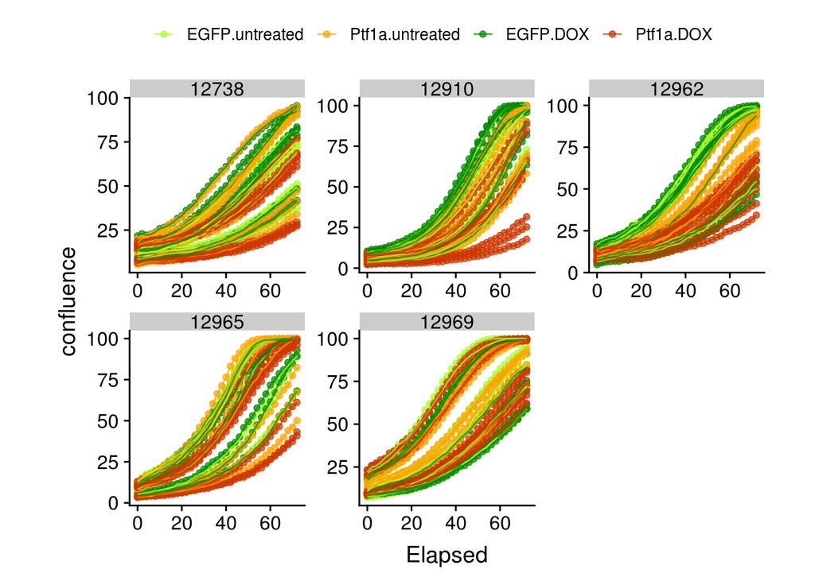

```r
fig1 <- ggplot(data_narrow,
               aes(x=Elapsed, y=confluence,
                   group=interaction(Experiment, gene, treatment, rep),
                   color=interaction(gene, treatment))) +
  geom_point(alpha=0.7) +
  geom_line(alpha=0.7) +
  scale_color_manual(values=c('greenyellow', 'orange', 'green4', 'orangered3')) +
  theme(aspect.ratio=1,
        legend.position='top',
        legend.title = element_blank(),
        legend.text = element_text(size=10)) +
  facet_wrap(facets=vars(Line), scales='free')

fig1
```

Well, this looks like hot garbage at first glance, although maybe there is something happening in a couple of lines: in 12738 and 12910, at least there are a bunch of slow-proliferating samples with Ptf1a +DOX, consistent with our hypothesis. But there are also several Ptf1a +DOX samples tucked in with the faster-proliferating samples, so is this just an artifact?

### Summarizing our data with `summarize` - a toy example

```r
data(mpg)
print(mpg)  # just to check what the data look like
```

```
## # A tibble: 234 x 11
##    manufacturer model displ  year   cyl trans drv     cty   hwy fl    class
##    <chr>        <chr> <dbl> <int> <int> <chr> <chr> <int> <int> <chr> <chr>
##  1 audi         a4      1.8  1999     4 auto… f        18    29 p     comp…
##  2 audi         a4      1.8  1999     4 manu… f        21    29 p     comp…
##  3 audi         a4      2    2008     4 manu… f        20    31 p     comp…
##  4 audi         a4      2    2008     4 auto… f        21    30 p     comp…
##  5 audi         a4      2.8  1999     6 auto… f        16    26 p     comp…
##  6 audi         a4      2.8  1999     6 manu… f        18    26 p     comp…
##  7 audi         a4      3.1  2008     6 auto… f        18    27 p     comp…
##  8 audi         a4 q…   1.8  1999     4 manu… 4        18    26 p     comp…
##  9 audi         a4 q…   1.8  1999     4 auto… 4        16    25 p     comp…
## 10 audi         a4 q…   2    2008     4 manu… 4        20    28 p     comp…
## # … with 224 more rows
```

First we need to **group the data**, in this case by cylinder, using `group_by`. This doesn’t change the data frame, but it imposes a layer of organization that we can use when we want to perform groupwise calculations, using `summarize`.

```r
# first we need to group the cars
mpg_by_cyl <- group_by(mpg, cyl) %>% print()
```

```
## # A tibble: 234 x 11
## # Groups:   cyl [4]
##    manufacturer model displ  year   cyl trans drv     cty   hwy fl    class
##    <chr>        <chr> <dbl> <int> <int> <chr> <chr> <int> <int> <chr> <chr>
##  1 audi         a4      1.8  1999     4 auto… f        18    29 p     comp…
##  2 audi         a4      1.8  1999     4 manu… f        21    29 p     comp…
##  3 audi         a4      2    2008     4 manu… f        20    31 p     comp…
##  4 audi         a4      2    2008     4 auto… f        21    30 p     comp…
##  5 audi         a4      2.8  1999     6 auto… f        16    26 p     comp…
##  6 audi         a4      2.8  1999     6 manu… f        18    26 p     comp…
##  7 audi         a4      3.1  2008     6 auto… f        18    27 p     comp…
##  8 audi         a4 q…   1.8  1999     4 manu… 4        18    26 p     comp…
##  9 audi         a4 q…   1.8  1999     4 auto… 4        16    25 p     comp…
## 10 audi         a4 q…   2    2008     4 manu… 4        20    28 p     comp…
## # … with 224 more rows
```

```r
# this has created a new tibble, but we can easily confirm that all elements of the data frame itself
#   are preserved from the original:
table(mpg_by_cyl==mpg)
```

```
##
## TRUE
## 2574
```

Now, the main event. Calling `summarize` allows us to perform as many groupwise operations as we want, and it will spit out a new data frame in which the grouping variable is on the left, followed by the output of whatever operations we performed. In this case, we will count the numbers of models within each cylinder group (`n`), and the `mean` and standard deviation (`sd`) of their highway mileage `hwy` and engine displacement `displ`.

```r
# identify and summarize car models within each cylinder group
mpg_cyl_summarize <- summarize(mpg_by_cyl,
                               n=n(), hwy_mean=mean(hwy), hwy_sd=sd(hwy),
                               displ_mean=mean(displ), displ_sd=sd(displ))
print(mpg_cyl_summarize)
```

```
## # A tibble: 4 x 6
##     cyl     n hwy_mean hwy_sd displ_mean displ_sd
##   <int> <int>    <dbl>  <dbl>      <dbl>    <dbl>
## 1     4    81     28.8   4.52       2.15    0.315
## 2     5     4     28.8   0.5        2.5     0
## 3     6    79     22.8   3.69       3.41    0.472
## 4     8    70     17.6   3.26       5.13    0.589
```

Hopefully this makes sense! (Also: who knew that there were five-cylinder engines?) But before we go back to the Incucyte data, let’s also see how easy it is to use the `%>%` pipe operator to get the same results without creating a bunch of new variables, while also preserving readable code.

```r
# first, without creating a new data frame, we will call "group_by" on the original data,
#   then pipe it to "summarize"
group_by(mpg, cyl) %>%
  summarize(n=n(), hwy_mean=mean(hwy), hwy_sd=sd(hwy), displ_mean=mean(displ), displ_sd=sd(displ))
```

```
## # A tibble: 4 x 6
##     cyl     n hwy_mean hwy_sd displ_mean displ_sd
##   <int> <int>    <dbl>  <dbl>      <dbl>    <dbl>
## 1     4    81     28.8   4.52       2.15    0.315
## 2     5     4     28.8   0.5        2.5     0
## 3     6    79     22.8   3.69       3.41    0.472
## 4     8    70     17.6   3.26       5.13    0.589
```

This is a great way to perform basic data exploration.

### Back to our data - combining technical replicates

Hopefully it is obvious what we need to do with our Incucyte `data_narrow`, but let’s first remind ourselves what the data look like.

```r
print(data_narrow)
```

```
## # A tibble: 6,636 x 8
##     Line Elapsed   Date Experiment gene  treatment rep   confluence
##    <dbl>   <dbl>  <dbl>      <dbl> <chr> <fct>     <chr>      <dbl>
##  1 12738       0 180116          1 EGFP  untreated 1           16.2
##  2 12738       2 180116          1 EGFP  untreated 1           18.1
##  3 12738       4 180116          1 EGFP  untreated 1           17.5
##  4 12738       6 180116          1 EGFP  untreated 1           18.0
##  5 12738       8 180116          1 EGFP  untreated 1           18.4
##  6 12738      10 180116          1 EGFP  untreated 1           19.4
##  7 12738      12 180116          1 EGFP  untreated 1           20.1
##  8 12738      14 180116          1 EGFP  untreated 1           21.3
##  9 12738      16 180116          1 EGFP  untreated 1           22.3
## 10 12738      18 180116          1 EGFP  untreated 1           23.1
## # … with 6,626 more rows
```

**We want to combine each set of technical replicates**, which means we need to `group_by` every other grouping variable - if we don’t include `gene` in our grouping, for example, the `summarize` function will eventually smoosh together the EGFP and Ptf1a results. **R is smart enough to be very stupid**, if we don’t give it careful instructions!

Then we will call `mean` and `sd` on the summarized data, and return the compressed data frame - and confirm that it is 1/3 the size of the original, due to compressing the triplicate data points.

```r
# calculate mean confluence across technical replicates
data_mean <- group_by(data_narrow, Line, Experiment, Date, Elapsed, gene, treatment) %>%
  summarize(conf_mean=mean(confluence), conf_sd=sd(confluence)) %>% print()
```

```
## # A tibble: 2,212 x 8
## # Groups:   Line, Experiment, Date, Elapsed, gene [1,106]
##     Line Experiment   Date Elapsed gene  treatment conf_mean conf_sd
##    <dbl>      <dbl>  <dbl>   <dbl> <chr> <fct>         <dbl>   <dbl>
##  1 12738          1 180116       0 EGFP  untreated      14.2   1.75
##  2 12738          1 180116       0 EGFP  DOX            18.6   2.68
##  3 12738          1 180116       0 Ptf1a untreated      14.8   2.54
##  4 12738          1 180116       0 Ptf1a DOX            15.2   0.991
##  5 12738          1 180116       2 EGFP  untreated      15.9   1.95
##  6 12738          1 180116       2 EGFP  DOX            20.0   2.58
##  7 12738          1 180116       2 Ptf1a untreated      16.9   3.19
##  8 12738          1 180116       2 Ptf1a DOX            17.0   0.972
##  9 12738          1 180116       4 EGFP  untreated      16.1   1.34
## 10 12738          1 180116       4 EGFP  DOX            19.8   2.06
## # … with 2,202 more rows
```

```r
data_mean <- ungroup(data_mean)  # this will be necessary later. and is a good idea generally

# the new data frame should be 1/3 the length of the original, since the triple replicates have been
#   collapsed down to one each - let's confirm
nrow(data_mean) == nrow(data_narrow)/3
```

```
## [1] TRUE
```

### Data inspection

Before we go back to growth curves, we can take a quick look at the data to see if there are any systematic errors present - e.g. is one of the conditions plagued by an unusual amount of variation? I find it useful to plot the *coefficient of variation*, $CV=SD/mean$, which is sort of a normalized standard deviation, as a function of the mean. In theory, all the samples should have similar CVs, and if we see that one set of samples stands out for for having unusually high CVs, it may indicate a systematic error (e.g. we only plated two wells instead of three). Here we will plot mean vs. CV for all observations, color-coded by cell line, transgene or DOX treatment status.

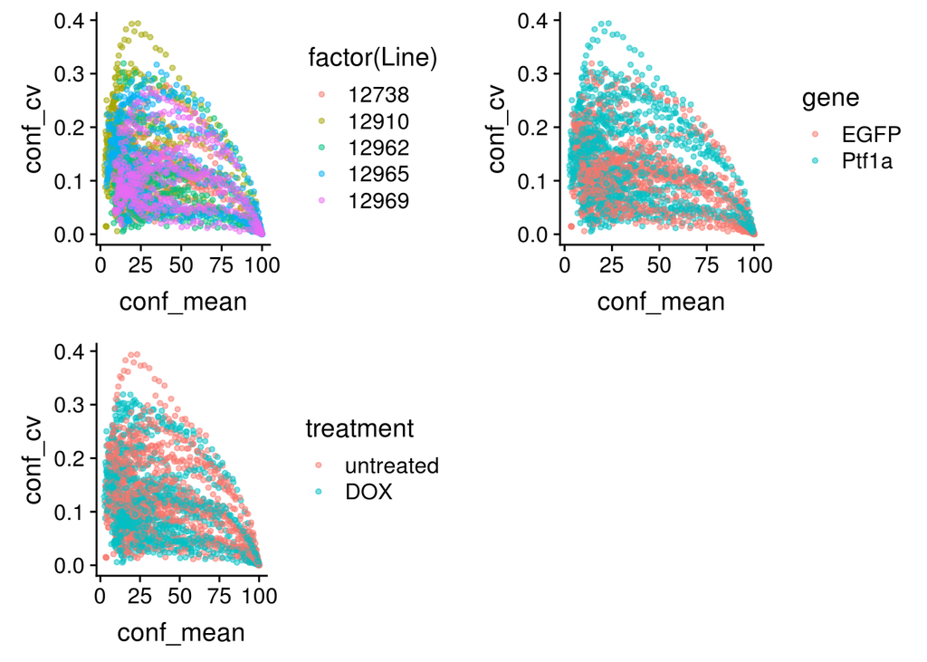

```r
# first, add CV as a column to our data frame
data_mean <- mutate(data_mean, conf_cv=conf_sd/conf_mean)

# create base plot
p <- ggplot(data_mean, aes(x=conf_mean, y=conf_cv))

# plot with various color coding schemes
p_line <- p + geom_point(aes(color=factor(Line)), alpha=0.5, size=1)
p_gene <- p + geom_point(aes(color=gene), alpha=0.5, size=1)
p_treatment <- p + geom_point(aes(color=treatment), alpha=0.5, size=1)

plot_grid(p_line, p_gene, p_treatment, align='h')
```

Two points to note:

- The plots are *not* just straight horizontal lines, and in fact there is a hint of an arc shape starting at the lower-left, curving up and then back down to the lower-right. If you think about what we are measuring (proliferation of cells within a fixed surface area), this may make sense.
- There is quite a bit of spread, especially on the left half of the graph, but there is no sign of systematic error, i.e. no condition is consistently associated with higher CV. This is real-world data, and sometimes things are noisy. The most variable samples don’t look like outliers.

Note that the above is a very amateurish approach to data inspection, but it is worth putting in at least some effort, early on, to make sure that your data doesn’t have some major problem that could later make it uninterpretable. The use of `ggplot` makes it particularly easy to see whether any grouping/descriptor variables, e.g. sex or genotype, is associated with large changes or aberrations in the data.

### A second figure

Now, let’s plot the mean and SD (as error bar) of each cell line/experiment. As before, we will plot individual points as well as lines connecting them - note that since we have collapsed the technical replicates into `conf_mean`, our `group=interaction` call needs only connect `Experiment`, `gene` and `treatment`.

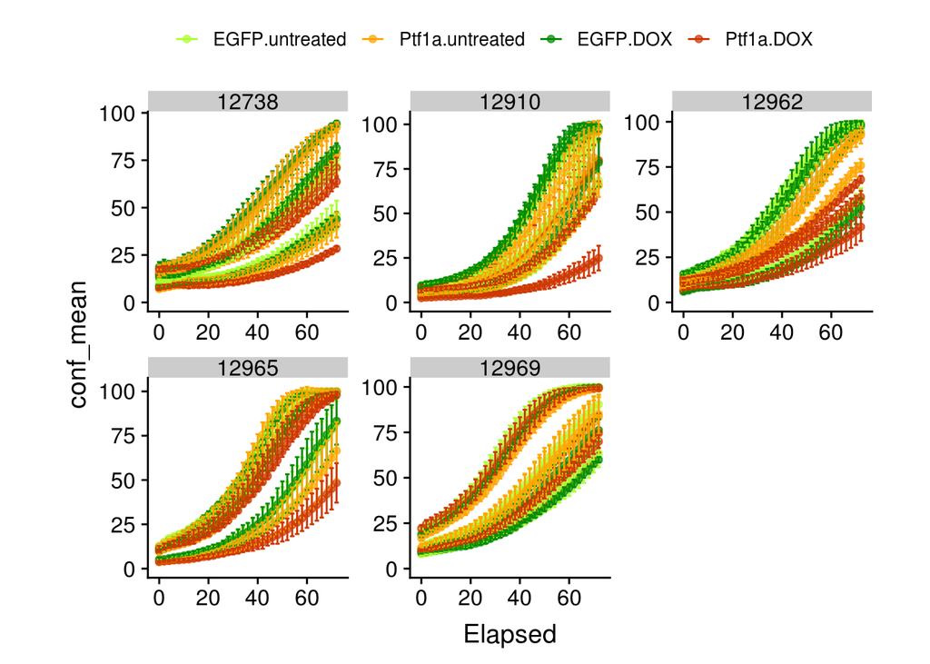

```r
fig2 <- ggplot(data_mean, aes(x=Elapsed, y=conf_mean,
                              group=interaction(Experiment, gene, treatment),
                              color=interaction(gene, treatment))) +
  geom_point(alpha=0.7) +
  geom_line(alpha=0.7) +
  geom_errorbar(aes(ymin=conf_mean-conf_sd, ymax=conf_mean+conf_sd)) +
  scale_color_manual(values=c('greenyellow', 'orange', 'green4', 'orangered3')) +
  expand_limits(y=0) +
  theme(aspect.ratio=1,
        legend.position='top',
        legend.title = element_blank(),
        legend.text = element_text(size=10)) +
  facet_wrap(facets=vars(Line), scales='free')

fig2
```

Things are starting to look a little cleaner, but there is still the confounding fact that in some cell lines, only some but not all of the Ptf1a +DOX samples appear to be slow-growing.

One potential explanation: between experiments, there appears to be inconsistency in terms of how confluent the cells were at the *start* of the experiment: if slow-growing cells were initially twice as dense, in one experiment, as fast-growing cells in another experiment, the difference in their growth kinetics might be hard to see.

Let’s do a quick bit of data exploration with another key Tidyverse function, **`filter`**.

### Examining subsets of data with `filter` - a toy example

`filter` is called with `filter(data, ...,)`, where `data` is, of course, your data frame of interest, and `...` is one or more logical arguments with which to evaluate your data. It returns a data frame containing the rows of `data` that satisfy the arguments in `...`. Let’s go back to our `mpg` data for a toy example.

We want to ask: *what carmakers make the best (top 25%) highway mileage models with automatic transmission?* To answer this, we will perform the following operations:

1. `filter` for automatic transmission models - using the awesome Tidyverse string-handling function `str_detect` on the `trans` column
2. `filter` again, now for models with `hwy` mileage above the 75th percentile (using base R function `quantile`)
3. `count` the number of models made per manufacturer
4. plot the result as a barplot, calling `reorder` to rank manufacturers by number of models

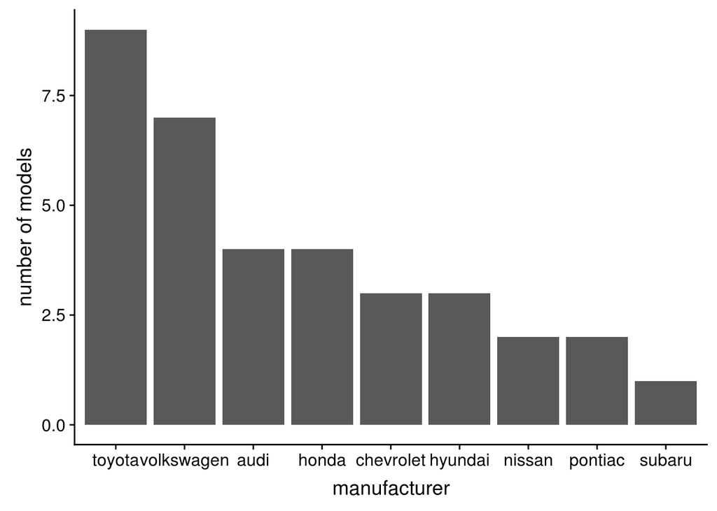

```r
# filter mpg data for top 25% highest highway mileage of automatic transmission cars, and graph
#   the number of models per manufacturer
filter(mpg, str_detect(trans, 'auto')) %>%
  filter(hwy > quantile(hwy, 0.75)) %>%
  count(manufacturer) %>%
  ggplot(aes(x=reorder(manufacturer, -n), y=n)) +
    geom_bar(stat='identity') +
    xlab('manufacturer') +
    ylab('number of models')
```

I’ve used `%>%` liberally in the above example, because of my fetish for R aesthetics, but you could get the same results just creating new data frames at each step, which also gives you more room to check how your code is working at each step:

```r
# doing the same thing with multiple steps
mpg_auto <- filter(mpg, str_detect(trans, 'auto')) %>% print()
```

```
## # A tibble: 157 x 11
##    manufacturer model displ  year   cyl trans drv     cty   hwy fl    class
##    <chr>        <chr> <dbl> <int> <int> <chr> <chr> <int> <int> <chr> <chr>
##  1 audi         a4      1.8  1999     4 auto… f        18    29 p     comp…
##  2 audi         a4      2    2008     4 auto… f        21    30 p     comp…
##  3 audi         a4      2.8  1999     6 auto… f        16    26 p     comp…
##  4 audi         a4      3.1  2008     6 auto… f        18    27 p     comp…
##  5 audi         a4 q…   1.8  1999     4 auto… 4        16    25 p     comp…
##  6 audi         a4 q…   2    2008     4 auto… 4        19    27 p     comp…
##  7 audi         a4 q…   2.8  1999     6 auto… 4        15    25 p     comp…
##  8 audi         a4 q…   3.1  2008     6 auto… 4        17    25 p     comp…
##  9 audi         a6 q…   2.8  1999     6 auto… 4        15    24 p     mids…
## 10 audi         a6 q…   3.1  2008     6 auto… 4        17    25 p     mids…
## # … with 147 more rows
```

```r
mpg_auto_best <- filter(mpg_auto, hwy > quantile(hwy, 0.75)) %>% print()
```

```
## # A tibble: 35 x 11
##    manufacturer model displ  year   cyl trans drv     cty   hwy fl    class
##    <chr>        <chr> <dbl> <int> <int> <chr> <chr> <int> <int> <chr> <chr>
##  1 audi         a4      1.8  1999     4 auto… f        18    29 p     comp…
##  2 audi         a4      2    2008     4 auto… f        21    30 p     comp…
##  3 audi         a4      3.1  2008     6 auto… f        18    27 p     comp…
##  4 audi         a4 q…   2    2008     4 auto… 4        19    27 p     comp…
##  5 chevrolet    mali…   2.4  1999     4 auto… f        19    27 r     mids…
##  6 chevrolet    mali…   2.4  2008     4 auto… f        22    30 r     mids…
##  7 chevrolet    mali…   3.5  2008     6 auto… f        18    29 r     mids…
##  8 honda        civic   1.6  1999     4 auto… f        24    32 r     subc…
##  9 honda        civic   1.6  1999     4 auto… f        24    32 r     subc…
## 10 honda        civic   1.8  2008     4 auto… f        25    36 r     subc…
## # … with 25 more rows
```

```r
mpg_auto_best_who <- count(mpg_auto_best, manufacturer) %>% print()
```

```
## # A tibble: 9 x 2
##   manufacturer     n
##   <chr>        <int>
## 1 audi             4
## 2 chevrolet        3
## 3 honda            4
## 4 hyundai          3
## 5 nissan           2
## 6 pontiac          2
## 7 subaru           1
## 8 toyota           9
## 9 volkswagen       7
```

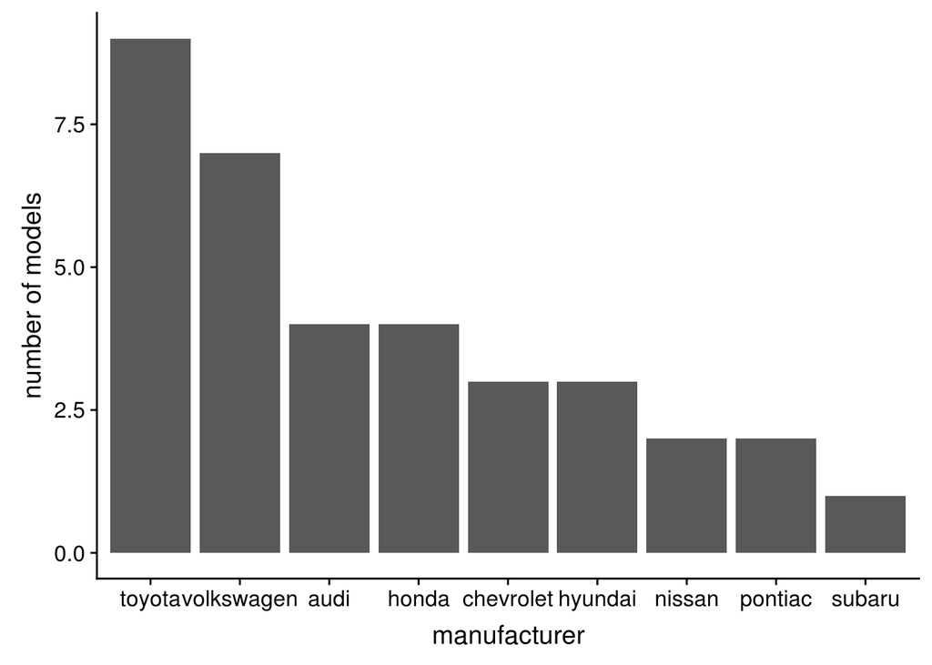

```r
ggplot(mpg_auto_best_who, aes(x=reorder(manufacturer, -n), y=n)) +
  geom_bar(stat='identity') +
  xlab('manufacturer') +
  ylab('number of models')
```

### Using `filter` to explore our data

Let’s remind ourselves what our data look like:

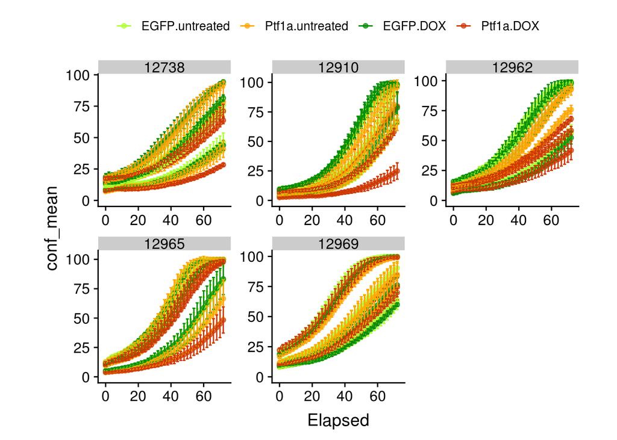

```r
fig2
```

Now, let’s filter the data to include only two timepoints, the beginning of the experiment and the end, and just graph these data points with a line connecting them. We will first `filter` for data points in which `Elapsed` is either at its minimum or maximum, using the OR operator `|`. Once we see this is good, we will plot the results.

```r
# filter for start and end of experiment, and graph
filter(data_mean, Elapsed == min(Elapsed)| Elapsed==max(Elapsed))
```

```
## # A tibble: 112 x 9
##     Line Experiment   Date Elapsed gene  treatment conf_mean conf_sd
##    <dbl>      <dbl>  <dbl>   <dbl> <chr> <fct>         <dbl>   <dbl>
##  1 12738          1 180116       0 EGFP  untreated     14.2    1.75
##  2 12738          1 180116       0 EGFP  DOX           18.6    2.68
##  3 12738          1 180116       0 Ptf1a untreated     14.8    2.54
##  4 12738          1 180116       0 Ptf1a DOX           15.2    0.991
##  5 12738          1 180116      72 EGFP  untreated     76.1    4.92
##  6 12738          1 180116      72 EGFP  DOX           94.3    1.58
##  7 12738          1 180116      72 Ptf1a untreated     78.5   11.1
##  8 12738          1 180116      72 Ptf1a DOX           63.7    2.70
##  9 12738          2 180120       0 EGFP  untreated      9.10   0.583
## 10 12738          2 180120       0 EGFP  DOX            8.42   0.816
## # … with 102 more rows, and 1 more variable: conf_cv <dbl>
```

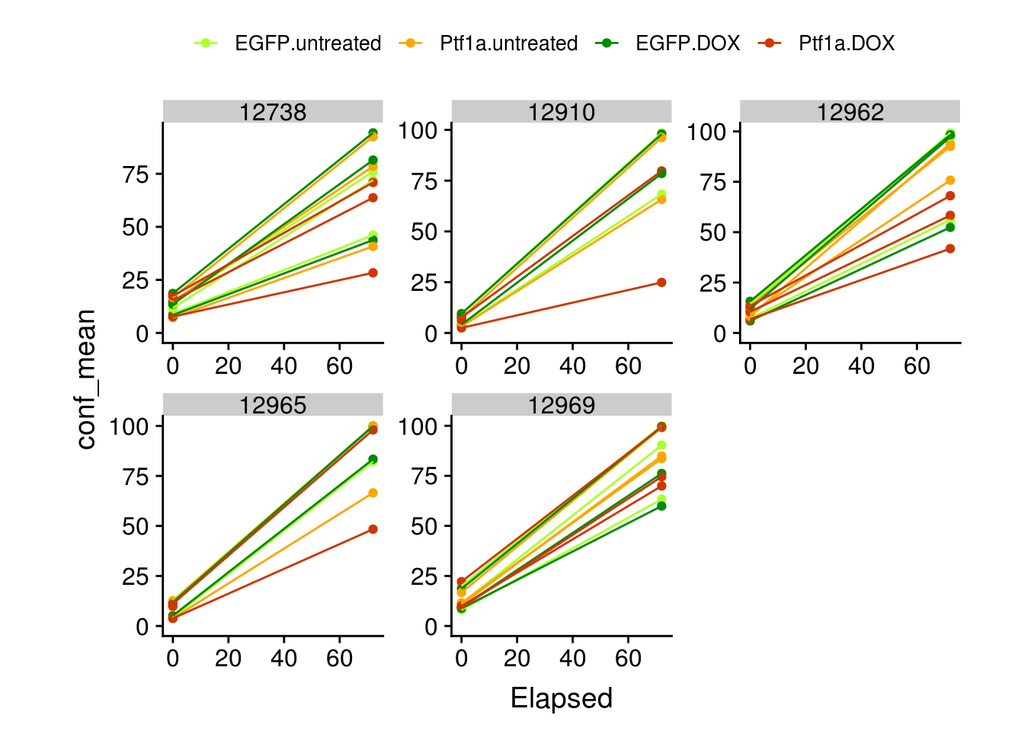

```r
filter(data_mean, Elapsed == min(Elapsed)| Elapsed==max(Elapsed)) %>%
  ggplot(aes(x=Elapsed, y=conf_mean,
             group=interaction(Experiment, gene, treatment),
             color=interaction(gene, treatment))) +
    geom_point() +
    geom_line() +
    scale_color_manual(values=c('greenyellow', 'orange', 'green4', 'orangered3')) +
    expand_limits(y=0) +
    theme(aspect.ratio=1,
        legend.position='top',
        legend.title = element_blank(),
        legend.text = element_text(size=10)) +
  facet_wrap(facets=vars(Line), scales='free')
```

Now it looks like something interesting is happening: in lines 12738, 12910 and 19262, there are Ptf1 +DOX samples that start out at a relatively high confluence, but end up lower than their t=0 neighbors. The results with 12965 are mixed, while in 12969 there seems to be no difference between Ptf1a +DOX and the others.

But we still would like to look at these data as actual *curves*. Maybe the right way to approach it would be to **normalize each experiment to its starting point**, i.e. express the data in terms of fold-change relative to t=0.

### Transforming our data by normalization to starting values

Approach:

1. create a new data frame containing the t=0 data, `baseline`, with `conf_mean` renamed to `initial`
2. merge `baseline` into `data_mean` data frame via **`inner_join`** - this will add the t=0 confluence as a new column, `initial`
3. create `fold`-normalized confluence by dividing `conf_mean` by `initial` - similar operation for standard deviation values
4. graph the results

Note that this is the first time that we are actually **transforming** our data, which is a step you should always think hard about - does it make sense to do this, or could I be introducing a new and unrecognized source of error? I’ll come back to this briefly at the very end.

```r
# create new data frame for initial confluence values, get rid of extraneous columns
baseline <- filter(data_mean, Elapsed==0) %>%
  rename(initial=conf_mean) %>%
  select(-Elapsed, -conf_sd, -conf_cv) %>% print()
```

```
## # A tibble: 60 x 6
##     Line Experiment   Date gene  treatment initial
##    <dbl>      <dbl>  <dbl> <chr> <fct>       <dbl>
##  1 12738          1 180116 EGFP  untreated   14.2
##  2 12738          1 180116 EGFP  DOX         18.6
##  3 12738          1 180116 Ptf1a untreated   14.8
##  4 12738          1 180116 Ptf1a DOX         15.2
##  5 12738          2 180120 EGFP  untreated    9.10
##  6 12738          2 180120 EGFP  DOX          8.42
##  7 12738          2 180120 Ptf1a untreated    7.24
##  8 12738          2 180120 Ptf1a DOX          7.70
##  9 12738          3 180319 EGFP  untreated   11.8
## 10 12738          3 180319 EGFP  DOX         13.5
## # … with 50 more rows
```

```r
# create new data set 'data_fold' by adding initial confluence variable to data_mean
# inner_join will re-use same 'initial' variables across all timepoints
data_fold <- inner_join(data_mean, baseline) %>% print()
```

```
## # A tibble: 2,212 x 10
##     Line Experiment   Date Elapsed gene  treatment conf_mean conf_sd
##    <dbl>      <dbl>  <dbl>   <dbl> <chr> <fct>         <dbl>   <dbl>
##  1 12738          1 180116       0 EGFP  untreated      14.2   1.75
##  2 12738          1 180116       0 EGFP  DOX            18.6   2.68
##  3 12738          1 180116       0 Ptf1a untreated      14.8   2.54
##  4 12738          1 180116       0 Ptf1a DOX            15.2   0.991
##  5 12738          1 180116       2 EGFP  untreated      15.9   1.95
##  6 12738          1 180116       2 EGFP  DOX            20.0   2.58
##  7 12738          1 180116       2 Ptf1a untreated      16.9   3.19
##  8 12738          1 180116       2 Ptf1a DOX            17.0   0.972
##  9 12738          1 180116       4 EGFP  untreated      16.1   1.34
## 10 12738          1 180116       4 EGFP  DOX            19.8   2.06
## # … with 2,202 more rows, and 2 more variables: conf_cv <dbl>,
## #   initial <dbl>
```

```r
# create new variable for fold-change over initial confluence (also standard deviation)
data_fold <- mutate(data_fold, fold=conf_mean/initial, fold_sd=conf_sd/initial) %>% print()
```

```
## # A tibble: 2,212 x 12
##     Line Experiment   Date Elapsed gene  treatment conf_mean conf_sd
##    <dbl>      <dbl>  <dbl>   <dbl> <chr> <fct>         <dbl>   <dbl>
##  1 12738          1 180116       0 EGFP  untreated      14.2   1.75
##  2 12738          1 180116       0 EGFP  DOX            18.6   2.68
##  3 12738          1 180116       0 Ptf1a untreated      14.8   2.54
##  4 12738          1 180116       0 Ptf1a DOX            15.2   0.991
##  5 12738          1 180116       2 EGFP  untreated      15.9   1.95
##  6 12738          1 180116       2 EGFP  DOX            20.0   2.58
##  7 12738          1 180116       2 Ptf1a untreated      16.9   3.19
##  8 12738          1 180116       2 Ptf1a DOX            17.0   0.972
##  9 12738          1 180116       4 EGFP  untreated      16.1   1.34
## 10 12738          1 180116       4 EGFP  DOX            19.8   2.06
## # … with 2,202 more rows, and 4 more variables: conf_cv <dbl>,
## #   initial <dbl>, fold <dbl>, fold_sd <dbl>
```

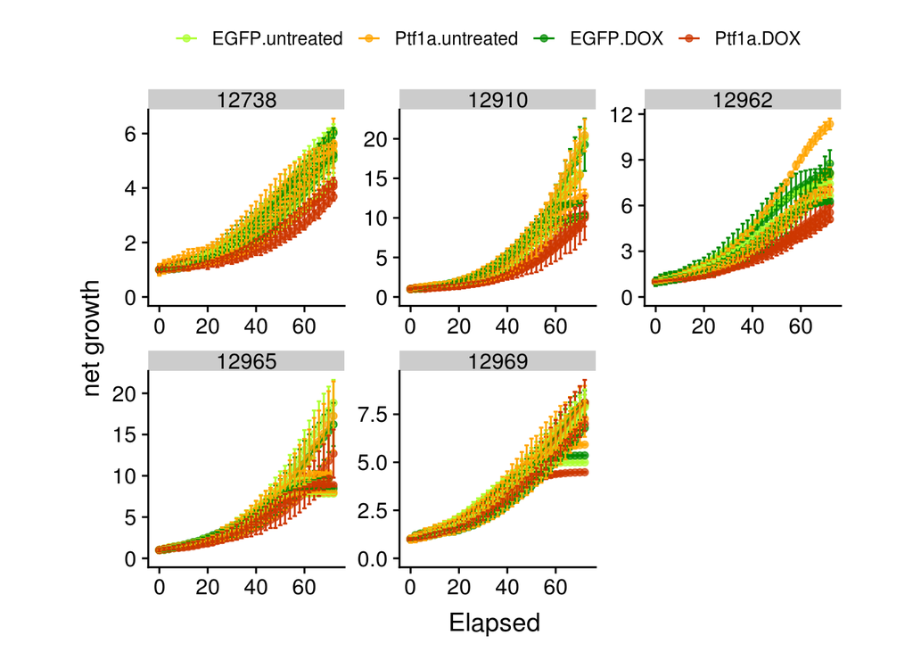

```r
# plot fold-change (with SD) for each cell line/experiment
fig3 <- ggplot(data_fold, aes(x=Elapsed, y=fold,
                              group=interaction(Experiment, gene, treatment),
                              color=interaction(gene, treatment))) +
  geom_point(alpha=0.7) +
  geom_line(alpha=0.7) +
  geom_errorbar(aes(ymin=fold-fold_sd, ymax=fold+fold_sd)) +
  scale_color_manual(values=c('greenyellow', 'orange', 'green4', 'orangered3')) +
  expand_limits(y=0) +
  theme(aspect.ratio=1) +
  ylab('net growth') +
  theme(aspect.ratio=1,
        legend.position='top',
        legend.title = element_blank(),
        legend.text = element_text(size=10)) +
  facet_wrap(facets=vars(Line), scales='free')

fig3
```

Now we are maybe getting somewhere! There is clearly reduced growth in all of the Ptf1a +DOX samples of lines 12738, 12910 and 12962, while the other two lines have less or no effect.

### Summarizing data across experiments

Now that we have transformed our data in a way that makes sense, it would be appropriate to pool *across* experiments, i.e. determine the mean and SD of the biological replicates (at this point we are still plotting error bars corresponding to technical replicates).

```r
# calculate mean fold-change (and SD) across experiments
data_fold_mean <- group_by(data_fold, Line, Elapsed, gene, treatment) %>%
  summarize(fold_mean=mean(fold), fold_mean_sd=sd(fold)) %>% print()
```

```
## # A tibble: 740 x 6
## # Groups:   Line, Elapsed, gene [370]
##     Line Elapsed gene  treatment fold_mean fold_mean_sd
##    <dbl>   <dbl> <chr> <fct>         <dbl>        <dbl>
##  1 12738       0 EGFP  untreated      1          0
##  2 12738       0 EGFP  DOX            1          0
##  3 12738       0 Ptf1a untreated      1          0
##  4 12738       0 Ptf1a DOX            1          0
##  5 12738       2 EGFP  untreated      1.06       0.0546
##  6 12738       2 EGFP  DOX            1.03       0.0364
##  7 12738       2 Ptf1a untreated      1.09       0.0460
##  8 12738       2 Ptf1a DOX            1.07       0.0507
##  9 12738       4 EGFP  untreated      1.09       0.0450
## 10 12738       4 EGFP  DOX            1.04       0.0261
## # … with 730 more rows
```

```r
ungroup(data_fold_mean)
```

```
## # A tibble: 740 x 6
##     Line Elapsed gene  treatment fold_mean fold_mean_sd
##    <dbl>   <dbl> <chr> <fct>         <dbl>        <dbl>
##  1 12738       0 EGFP  untreated      1          0
##  2 12738       0 EGFP  DOX            1          0
##  3 12738       0 Ptf1a untreated      1          0
##  4 12738       0 Ptf1a DOX            1          0
##  5 12738       2 EGFP  untreated      1.06       0.0546
##  6 12738       2 EGFP  DOX            1.03       0.0364
##  7 12738       2 Ptf1a untreated      1.09       0.0460
##  8 12738       2 Ptf1a DOX            1.07       0.0507
##  9 12738       4 EGFP  untreated      1.09       0.0450
## 10 12738       4 EGFP  DOX            1.04       0.0261
## # … with 730 more rows
```

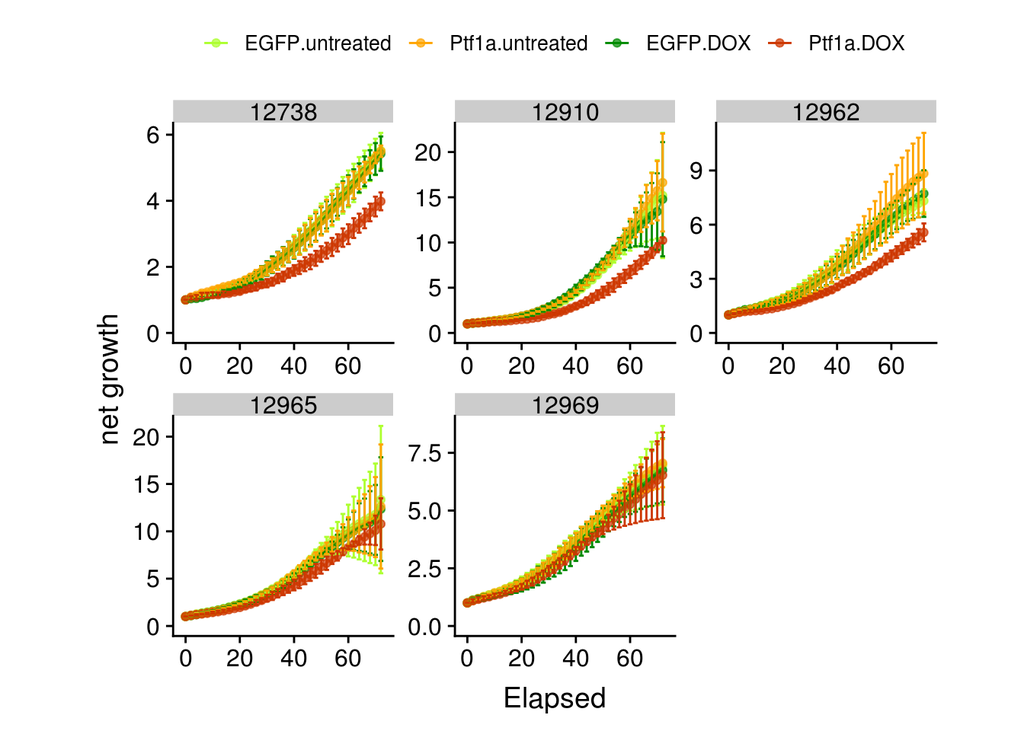

```r
# plot mean fold-change (with SD) for each cell line
fig4 <- ggplot(data_fold_mean, aes(x=Elapsed, y=fold_mean,
                                   group=interaction(gene, treatment),
                                   color=interaction(gene, treatment))) +
  geom_point(alpha=0.7) +
  geom_line(alpha=0.7) +
  geom_errorbar(aes(ymin=fold_mean-fold_mean_sd, ymax=fold_mean+fold_mean_sd)) +
  scale_color_manual(values=c('greenyellow', 'orange', 'green4', 'orangered3')) +
  expand_limits(y=0) +
  theme(aspect.ratio=1) +
  ylab('net growth') +
  theme(aspect.ratio=1,
        legend.position='top',
        legend.title = element_blank(),
        legend.text = element_text(size=10)) +
  facet_wrap(facets=vars(Line), scales='free')

fig4
```

Now this is looking relatively convincing: lines 12738, 12910 and 12962 all show a clear and specific inhibition of growth with Ptf1a expression, while the other two lines are weakly or non-responsive to Ptf1a.

Just to pretty things up and give our eyes something to grab on to (and which we can potentially use for statistical analysis down the road), let’s calculate the half-maximal net growth within each cell lines, and add it to the plot as a horizontal line. We can then compare long it takes for each line to reach a set growth point, well before any of them hits confluence. Note that there are R packages for formal statistical analyses of growth data, such as `growthcurver`, and you can also use R to estimate the time to half-maximal growth using a statistical model (e.g. `loess`) and the `predict` function - but thankfully that’s way outside the scope of this lecture!

```r
# calculate maximum mean fold change within each cell line, add half-max value to graphs
max_mean <- group_by(data_fold_mean, Line) %>% summarize(max=max(fold_mean)) %>% print()
```

```
## # A tibble: 5 x 2
##    Line   max
##   <dbl> <dbl>
## 1 12738  5.51
## 2 12910 16.6
## 3 12962  8.83
## 4 12965 13.3
## 5 12969  7.05
```

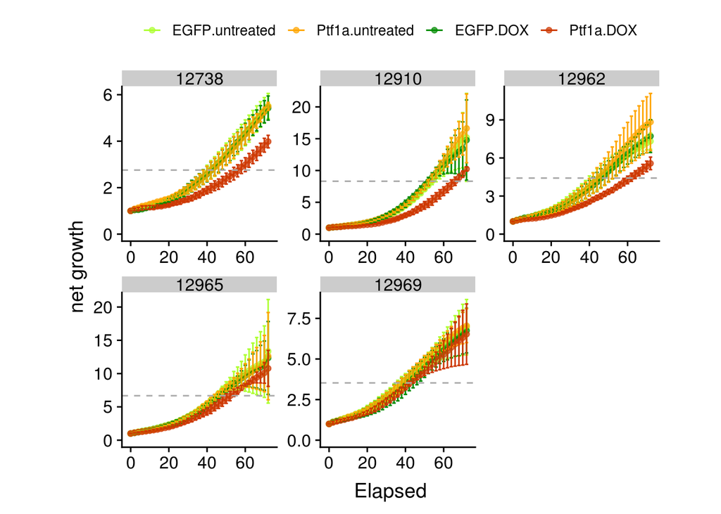

```r
fig4 <- fig4 + geom_hline(data=max_mean, aes(yintercept=max/2), col='darkgray', lty='dashed')

fig4
```

Finally, let’s look at all these representations of the data, as we have combined and transformed them from the raw Incucyte results.

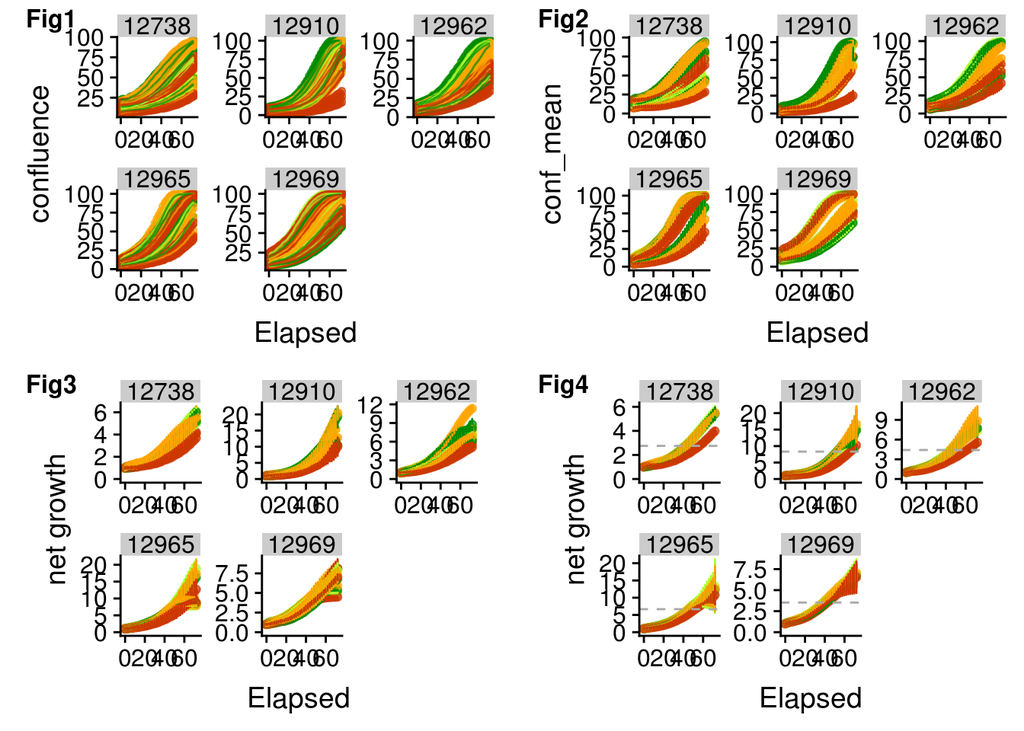

```r
plot_grid(fig1 + theme(legend.position = "none"),
          fig2 + theme(legend.position = "none"),
          fig3 + theme(legend.position = "none"),
          fig4 + theme(legend.position = "none"),
          labels=c('Fig1', 'Fig2', 'Fig3', 'Fig4'),
          label_size=12)
```

To quote the Virginia Slims cigarette ad, **you’ve come a long way, baby**.